# Project 1: Test a Perceptual Phenomenon

## Question 1: What is our independent variable? What is our dependent variable?

Independent Variable: The test condition whether it is "congruent" or "incongruent"

Dependent variable: The response time in seconds

## Question 2: What is an appropriate set of hypotheses for this task? What kind of statistical test do you expect to perform?

Null hypothesis (H0): The average response time is the same for the congruent and incongruent conditions

Alternative hypothesis (H1): There is a significant difference between the average response time for the congruent task and the incongruent task

- H0: μi ≤ μc (μi - population mean of incongruent values, μc - population mean of congruent values)
- H1: μi > μc (μi - population mean of incongruent values, μc - population mean of congruent values)

Appropriate test: A dependent two-tailed t-test will be appropriate for this data set to compare the two dependent data samples. We will not conduct a z-test because of the small dataset and we do not have the population standard deviation

## Question 3: Report some descriptive statistics regarding this dataset.

```python
%matplotlib inline
import matplotlib.pyplot as plt
import numpy as np
import pandas as pd
import math
```

```python
stroop_data = pd.read_csv("stroopdata.csv")
stroop_data['difference']=stroop_data['Congruent']-stroop_data['Incongruent']
stroop_data.describe()
```

|  | Congruent | Incongruent | difference |
| --- | --- | --- | --- |
| count | 24.000000 | 24.000000 | 24.000000 |
| mean | 14.051125 | 22.015917 | -7.964792 |
| std | 3.559358 | 4.797057 | 4.864827 |
| min | 8.630000 | 15.687000 | -21.919000 |
| 25% | 11.895250 | 18.716750 | -10.258500 |
| 50% | 14.356500 | 21.017500 | -7.666500 |
| 75% | 16.200750 | 24.051500 | -3.645500 |
| max | 22.328000 | 35.255000 | -1.950000 |

- Congruent mean: 14.05
- Congruent std: 3.56
- Incongruent mean: 22.02
- Incongruent std: 4.80
- Sample difference mean: -7.97
- Sample difference std: 4.86

## Question 4: Provide one or two visualizations that show the distribution of the sample data. Write one or two sentences noting what you observe about the plot or plots.

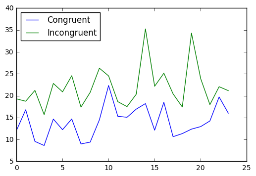

```python
plt.plot(stroop_data['Congruent'])
plt.plot(stroop_data['Incongruent'])
plt.legend(['Congruent', 'Incongruent'], loc='upper left')
plt.show()
```

It is obvious from the plot that congruent tasks consistently take less time to solve than incongruent tasks.

## Question 5: Statistical tests

```python
from scipy import stats
stats.ttest_rel(stroop_data['Congruent'], stroop_data['Incongruent'])
```

```
Ttest_relResult(statistic=-8.020706944109957, pvalue=4.1030005857111781e-08)
```

- Confidence level = 95% (alpha = 0.05)
- t-critical = +2.06,-2.06

t-statistic = -8.02 < t-critical = -2.06

The null-hypothesis is rejected with 95% confidence level. The response time for congruent test is significantly less than the response time for incongruent test.

The results match common sense, it is easier to respond to the congruent set

## References

https://en.wikipedia.org/wiki/Stroop_effect